# Homework 7: Graphs and Networks

### 2. Isomorphism

Draw all graphs with four nodes and four edges, up to isomorphism.

2)

We will assume simple graphs. If $|V|=4$ and we don't restrict the number of edges, then there are $11$ possible, unique configurations. The max number of possible edges is $\binom{|V|}{2}= \binom{4}{2} = 6.$ We can write this in python via:

```
from scipy.special import comb
comb(4,2)
```

If $|E|=4,$ then there are $2$ unique configurations, which we show below. Here are some good resources:

- http://www.graphclasses.org/smallgraphs.html#nodes4
- https://www.math3ma.com/blog/up-to-isomorphism
- https://www.wikiwand.com/en/Graph_isomorphism

**Grading Breakdown:**

```
5pts per graph with four nodes and four edges, up to isomorphism
```

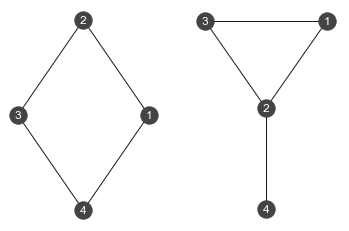

```python
G1 = nx.Graph()
G1.add_nodes_from(range(1,5)) # V: 4 nodes
G1.add_edges_from([(1,2),(2,3),(3,4),(4,1)]) # E: 4 Edges

G2 = nx.Graph()
G2.add_nodes_from(range(1,5)) # V: 4 nodes
G2.add_edges_from([(1,2),(2,3),(2,4),(3,1)]) # E: 4 Edges

basic_graph,ax = plt.subplots(1,2)
nx.draw(G1, ax=ax[0], pos=nx.kamada_kawai_layout(G1),with_labels=True, node_color='#444444',font_color="white")
nx.draw(G2, ax=ax[1], pos=nx.kamada_kawai_layout(G2),with_labels=True, node_color='#444444',font_color="white")
```

### 3. Bipartite Graphs

a) What is the greatest number of edges a connected bipartite graph with $5$ nodes can have? Draw all five node graphs with this number of edges up to isomorphism.

b) What is the least number of edges a connected bipartite graph with $5$ nodes can have? Draw all five node graphs with this number of edges up to isomorphism.

**Grading Breakdown:**

```
2pts (a) for finding the greatest number of edges a connected bipartite graph with 5 nodes can have
3pts (a) for drawing the one graph
2pts (b) for finding the least number of edges a connected bipartite graph with 5 nodes can have
3pts (b) for drawing all three graphs (it's the first three below. Note that other answers could be isomorphic to mine)
```

Recall that given an undirected graph, $G=(V,E)$, a **path** from node $u$ to a distinct node $v$ is an alternating sequence of nodes and edges that:

- Begins at $u$,
- Ends at $v$, and
- No vertex is repeated, (i.e, each vertex is visited at most once).

Note that the length of a path is the number of edges in it.

Let $G$ be an undirected graph and let $S \subseteq V$. We say that $S$ is a **connected component** (also often called a strongly connected component) $\iff$ the following hold:

- **Reachability**: the condition $P(S)$ holds.

  $P(S):$ for any two vertices $u,v \in S$, if $u \neq v$ then there is a path in $G$ from $u$ to $v,$ and the path involves only those vertices that appear in $S$ (in other words, we cannot have the path use a vertex outside the set $S$).
- **Maximality**: for any $v\in V - S$, the condition $P(S\cup \{v\})$ does not hold. (i.e. Adding any other vertex to the set stops it from being a connected component.)

A **connected bipartite graph** satisfies the following:

- Nodes can be divided into two disjoint sets $U$ and $V$ (i.e. $U$ and $V$ are each independent sets) such that every edge in the graph connects a node in $U$ to a node in $V$.
- There is a path between every pair of nodes, regardless of the set that they are in. However, there can be no edges between vertices within $U$ or no edges between vertices within $V$.

3.a)

The greatest number of edges a connected bipartite graph with $5$ nodes can have is $6$. We will enumerate all the possible configurations below:

```python
G1 = nx.Graph(); G1.add_nodes_from(list(range(1,2)),bipartite=0); G1.add_nodes_from(['a','b','c','d'],bipartite=1);
G1.add_edges_from([(1,'a'),(1,'b'),(1,'c'),(1,'d')])

# Build the graphs. Define disjoint sets U, V
G2 = nx.Graph();
G2.add_nodes_from(list(range(1,3)),bipartite=0); # Explicitly define the set U
G2.add_nodes_from(['a','b','c'],bipartite=1); # Explicitly define the set V
G2.add_edges_from([(1,'a'),(1,'b'),(2,'b'),(2,'c')]) # Manually define the edges

# We'll write the rest in a more compact format
G3 = nx.Graph(); G3.add_nodes_from(list(range(1,3)),bipartite=0); G3.add_nodes_from(['a','b','c'],bipartite=1);
G3.add_edges_from([(1,'a'),(1,'b'),(1,'c'),(2,'b')])

G4 = nx.Graph(); G4.add_nodes_from(list(range(1,3)),bipartite=0); G4.add_nodes_from(['a','b','c'],bipartite=1);
G4.add_edges_from([(1,'a'),(1,'b'),(1,'c'),(2,'a'),(2,'b')])

G5 = nx.Graph(); G5.add_nodes_from(list(range(1,3)),bipartite=0); G5.add_nodes_from(['a','b','c'],bipartite=1);
G5.add_edges_from([(1,'a'),(1,'b'),(1,'c'),(2,'a'),(2,'b'),(2,'c')])
```

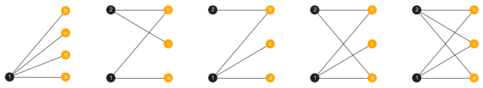

```python
Gs = [G1,G2,G3,G4,G5]

# Plot the graphs
basic_graph,ax = plt.subplots(1,5,figsize=(17,3))

plt.subplots_adjust(wspace=0.5)

# Color the disjoint sets U and V differently
nc = ['k']*2 + ['orange']*3
nc_G1 = ['k'] + ['orange']*4

# Draw the |U|=1, |V|=4 connected bipartite graph
nx.draw(G1, ax=ax[0], with_labels=True, pos=nx.bipartite_layout(G1,[1]), node_color= nc_G1, font_color="white")

for i,g in enumerate(Gs[1:]):
    nx.draw(g, ax=ax[i+1], with_labels=True, pos=nx.bipartite_layout(g,[1,2]), node_color=nc, font_color="white")
```

3.b)

From the possibilities above we see that the least number of edges a connected bipartite graph with $5$ nodes can have is $4$.

Interesting resources:

- https://www.cs.colorado.edu/~yuvo9296/courses/csci2824/sect33-graphs2.html
- https://www.whitman.edu/mathematics/cgt_online/book/section05.04.html
- https://math.stackexchange.com/questions/858426/connected-bipartite-graph
- http://mathworld.wolfram.com/BipartiteGraph.html
- https://www.math3ma.com/blog/matrices-probability-graphs
- https://github.com/thorehusfeldt/tutte_bhkk

### 4. Cycles

Define and draw a graph that decomposes into three non-overlapping cycles and whose maximal degree is $4$.

**Grading Breakdown:**

```
5pts if the graph decomposes into three non-overlapping cycles
2pt  for drawing the graph
3pts if the maximal degree is 4
```

4)

Let $G=(V,E)$ such that $V=\{1,2,3,4,5\}$ and $E=\{(1,2),(1,3),(1,4),(1,5),(2,3),(2,5),(3,4)\}$. Recall that the **degree of a node** of a graph, $G$, is the number of edges that are incident to the node. Moreover, the **maximum degree of $G$** is the maximum degree of its nodes. (Similarly, with its minimum).

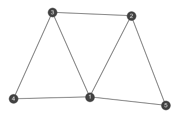

```python
# Cycles have nodes 0...n-1 and edges (i,i+1 mod n) for 0<=i<=n-1.

G = nx.Graph()
G.add_nodes_from(list(range(1,6))) # V: 4 nodes
G.add_edges_from([(1,2),(2,3),(3,4),(4,1),(1,5),(2,5),(1,3)]) # 4 Edges
basic_graph,ax = plt.subplots(1,1)
nx.draw(G, ax=ax, pos=nx.kamada_kawai_layout(G),with_labels=True, node_color='#444444',font_color="white")
```

### 5. Hamiltonian Circuits

Consider the set of square grid graphs like those returned by the function `nx.grid_graph(dim=[n,n])` where $n>0$. Show that these graphs always have a Hamilton Circuit when $n$ is even. Use networkx to draw the square grid graph for $n=6$, highlighting a Hamilton cycle.

**Grading Breakdown:**

```
2pts for using some logical argument to show that these graphs always have a Hamilton Circuit (HC) when n is even
3pts defining a HC route or writing an algorithm to find a Hamilton Circuit for n=6 case
2pts for using networkx to draw the square grid graph for n=6
3pts for highlighting a Hamilton Circuit in your graph
```

5.)

Recall that a circuit that uses every vertex in a graph exactly once is called a **Hamilton circuit**.

In the case of a $n\times n$ grid we can alway construct a Hamilton Circuit if $n$ is even, but if $n$ is odd the best we can do is construct a Hamilton Path (one such example is a spiral starting from the center point).

**Proof (via contradiction and construction):**

Suppose $n$ is even and there does not exist a HC. Then we cannot find a connected path such that every node is visited only once. However, $n=6$ is an even number, and the plot below shows a realization of a cycle that visits each node only once. Such a path is a HC by definition. Thus, we've arrived at a contradiction. Repeat this for each even $n$.

```python
def route_graph(route):
    """Turns a list into a graph"""
    R = nx.Graph()
    R.add_nodes_from(route)
    for i in range(len(route)-1):
        R.add_edge(route[i], route[i+1])
    return R
```

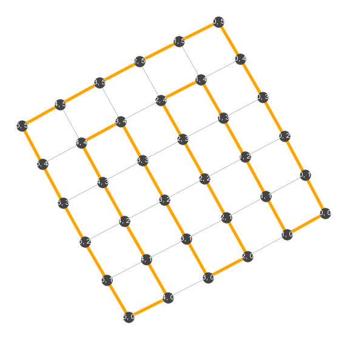

```python
n = 6
G = nx.grid_graph(dim=[n,n]) # make 6x6 grid graph

route = [(0,5),(0,4),(0,3),(0,2),(0,1),(0,0),
         (1,0),(1,1),(1,2),(1,3),(1,4),
         (2,4),(2,3),(2,2),(2,1),(2,0),
         (3,0),(3,1),(3,2),(3,3),(3,4),
         (4,4),(4,3),(4,2),(4,1),(4,0),
         (5,0),(5,1),(5,2),(5,3),(5,4),(5,5),
         (4,5),(3,5),(2,5),(1,5),(0,5)]

R = route_graph(route) # convert the route to a graph

basic_graph,ax = plt.subplots(1,1, figsize=(10,10))

edge_colors = ["orange" if R.has_edge(u,v) else "gray" for u,v in G.edges] # color the route oragne
edge_widths = [5 if R.has_edge(u,v) else 0.5 for u,v in G.edges]

nx.draw(G,
        pos=nx.kamada_kawai_layout(G),
        ax=ax, with_labels=True,
        node_color='#444444',
        font_color="white",
        edge_color = edge_colors,
        width = edge_widths)
```

**Some conclusions:**

- Given an $n\times m$ grid, long as either $n$ or $m$ is even, we can construct a Hamilton Circuit.
- On an even $n\times n$ grid, $G_n=(V_n,E_n)$, with boundary edges, $\partial \Omega_n$, there exists a Hamilton Circuit, $H_n = (V_{HC_n},E_{HC_n})$,such that

$$\begin{align} |V_n| &= |V_{HC_n}|=|E_{HC_n}| \text{ assuming } n\geq 2 \\ &= |\partial\Omega_n| + |E_{HC_{n-2}}| \text{ assuming } n\geq 4 \end{align} $$

- Algorithm Idea: Given a even $n \times n$ grid, such that $n \geq 4$, we can construct a Hamilton Circuit by embedding the Hamilton Circuit of an $(n-2)$ grid in the interior points, creating a path along the boundary points, $\partial \Omega$, then changing 1 edge in the boundary and 1 in the interior Hamilton Circuit to connect the two paths.
- As long as there exists a central squqre of $4$ nodes in an $n\times n$ grid, there exists a Hamilton Circuit.
- Any $n\times m$ grid has a Hamilton Path.

Interesting resources:

- https://courses.lumenlearning.com/math4liberalarts/chapter/introduction-euler-paths/
- https://www.whitman.edu/mathematics/cgt_online/book/section05.03.html

### 6. Spanning Trees and Hamilton Paths

In the spanning tree algorithm presented in class (and in the Jupyter notebook for this week), the spanning tree algorithm always starts with node zero. Furthermore, it always chooses the first neighbor of $v$ (in the `v.pop()` line). Thus, when the approximate Hamilton Cycle algorithm finds a spanning tree, it always gets the same one.

**Modify the spanning tree function to choose a random starting point and a random neighbor. Then write a wrapper around the code for the approximate Hamilton Cycle algorithm that runs it 10 times and returns the shortest cycle found.**

**Grading Breakdown:**

```
2pts for modifying the spanning tree function to choose a random starting point
1pt  for modifying the spanning tree function to choose a random neighbor
2pts for including the helper functions from the lecture notes: DFS, DFS_aux, route_graph
1pt  for creating a random test graph G
1pt  for writting a wrapper function and including a docstring in the wrapper
2pt  for updating the shortest route and graph in the loop
1pt  for returning the shortest cycle found
```

```python
# Modify the spanning tree function to choose a random starting point and a random neighbor.
def spanning_tree(G):
    """
    Assumes: G is a graph
    Returns: a spanning tree of the graph G if one exists, otherwise
       raises an exception.
    """

    # Initialize
    V = {np.random.choice(list(G.nodes))} # <------------- code to start with a random choice of node
    E = set({})

    while len(V) < len(G.nodes):

        # find a node u in V that has a neighbor v in notV
        v = None
        for u in V:
            nbrs = set(G.neighbors(u)) - V # .neighbors(u) returns a list of the nodes connected to the node u
            if len(nbrs) > 0:              # <------------- code to start with random neighbor
                temp = copy.deepcopy(nbrs) # Make a true copy. This function is necessary
                nbrs.remove(random.sample(nbrs, 1)[0]) # removes a random element from nbrs
                v = (temp - nbrs).pop() # temp - nbrs = the set of the element that was removed and .pop() removes and returns it
                break

        # If no v is found, then return an exception
        if v == None:
            raise Exception("Graph is not connected")

        V.add(v) # Add that node to V

        E.add((u,v)) # Add the edge uv to E

    # Build the graph
    T = nx.Graph()
    T.add_nodes_from(V)
    T.add_edges_from(E)

    return T
```

```python
# Suroutines for for finding approximate HAMILTON CYCLE

# Global variable for storing the nodes visited during depth first search
route = []

def DFS(T):
    """Given a tree T, do a depth first search starting
       with the first node. Returns a list of nodes visited,
       including repeats of nodes revisited when backtracking."""
    global route
    route = []
    for v in T.nodes:
        T.nodes[v]["visited"] = False;
    v = list(T.nodes)[0]
    DFS_aux(T,v)
    return route

def DFS_aux(T,v):
    """Auxilliary method for depth first search"""
    global route
    route.append(v)
    T.nodes[v]["visited"] = True
    children = [u for u in T.neighbors(v) if not T.nodes[u]["visited"]]
    for child in children:
        DFS_aux(T,child)
        route.append(v)

def shorten(G,route):
    """Given a graph G and a route, shorten the route as much
       as possible."""
    new_route = shorten_by_one(G,route)
    while len(new_route) < len(route):
        route = new_route
        new_route = shorten_by_one(G,route)
    return new_route

def shorten_by_one(G,route):
    """Given a graph G and a sequence of nodes in route, try to find a
       repeated node that can be skipped. Return the new route if such a
       node can be found, or the given route if not."""
    repeats = [v for v in route[1:-1] if route.count(v) > 1]
    random.shuffle(repeats) # avoids always picking 0
    for r in repeats:
        for i,v in enumerate(route):
            if route[i] == r and i != 0 and i != len(route) - 1:
                x,y = route[i-1], route[i+1]
                if G.has_edge(x,y):
                    return route[0:i] + route[i+1:]
    return route

# Note that route_graph(route) is already defined in a previous problem
```

```python
# Construct a random graph to test  HAMILTON CIRCUIT algorithms
n = 10
G = nx.fast_gnp_random_graph(n,0.75)
```

```python
def myWrapper(G):
    '''
    Assumes: G is a graph.
    Returns: The shortest approximate Hamiltonian Cycle found in 10 iterations
    '''
    shortest = 100 # initialize to somethings obviously too big
    myR = G

    for i in range(10):
        T = spanning_tree(G) # Find a spanning tree

        route = shorten(G,DFS(T)) # Do depth first search and shortening

        R = route_graph(route) # Turn the result into a networkx graph

        print("Route has length %d" % (len(route)-1))

        if (len(route)-1) < shortest: # Save the shortest graph and remember its route length
            myR = R
            shortest = len(route)-1
            print('The shortest is now',shortest)

        if (len(route)-1) == n: # Exit upon finding optimal route
            print("Optimal!!!")
            break

    return myR

R = myWrapper(G)
```

```
Route has length 12
The shortest is now 12
Route has length 11
The shortest is now 11
Route has length 11
Route has length 11
Route has length 11
Route has length 14
Route has length 12
Route has length 13
Route has length 13
Route has length 10
The shortest is now 10
Optimal!!!
```

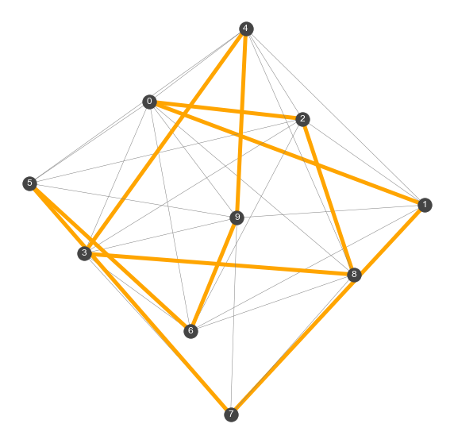

```python
# Draw the graph with the circuit highlighted
fig,ax = plt.subplots(1,1,figsize=(10,10))

edge_colors = ["orange" if R.has_edge(u,v) else "gray" for u,v in G.edges]
edge_widths = [5 if R.has_edge(u,v) else 0.5 for u,v in G.edges]

nx.draw(G,
        pos=nx.kamada_kawai_layout(G),
        ax=ax, with_labels=True,
        node_color='#444444',
        font_color="white",
        edge_color = edge_colors,
        width = edge_widths)
```